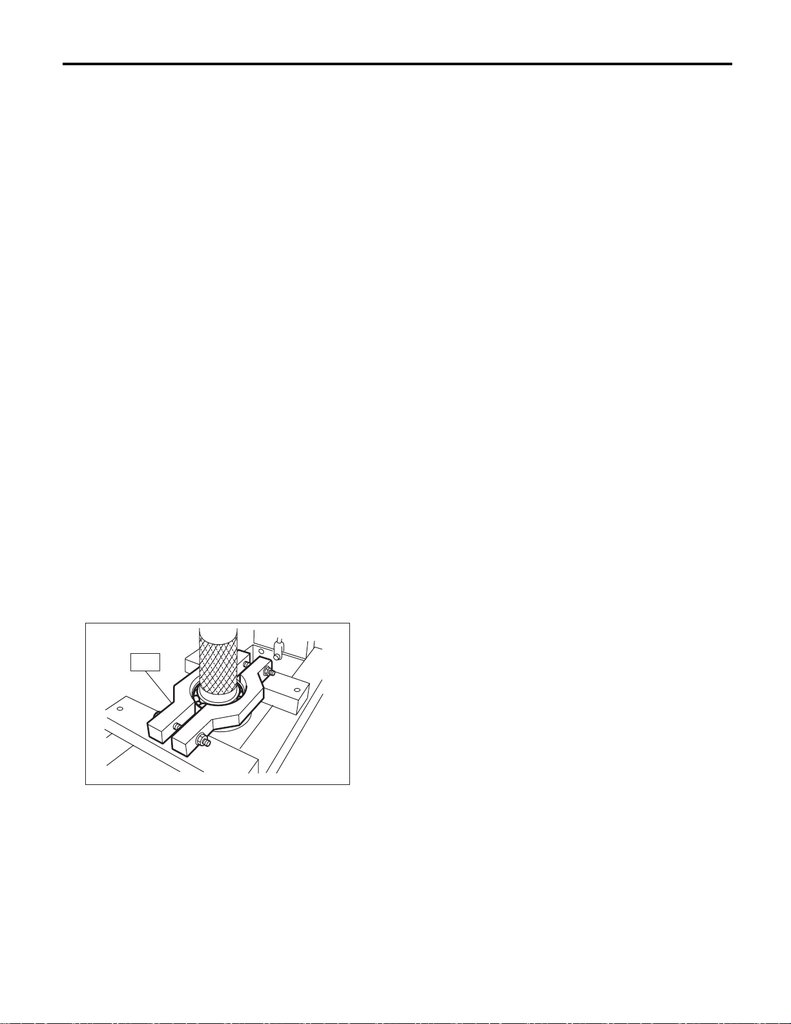

Center Differential

MANUAL TRANSMISSION AND DIFFERENTIAL

13.Center Differential

A: REMOVAL

1) Remove the manual transmission assembly from the vehicle. <Ref. to 6MT(TY75)-25, REMOVAL, Manual

Transmission Assembly.>

2) Remove the back-up light switch and the neutral position switch. <Ref. to 6MT(TY75)-45, REMOVAL,

Switches and Harness.>

3) Remove the transfer case together with the extension case assembly. <Ref. to 6MT(TY75)-51, REMOV-

AL, Transfer Case and Extension Case Assembly.>

4) Remove the extension case assembly. <Ref. to 6MT(TY75)-51, REMOVAL, Transfer Case and Extension

Case Assembly.>

5) Remove the center differential and transfer driven gear as a unit. <Ref. to 6MT(TY75)-65, REMOVAL,

Transfer Driven Gear.>

B: INSTALLATION

1) Install the center differential and transfer driven gear into the transfer case as a unit. <Ref. to 6MT(TY75)-

66, INSTALLATION, Transfer Driven Gear.>

2) Select the adjusting washer. <Ref. to 6MT(TY75)-53, INSTALLATION, Transfer Case and Extension Case

Assembly.>

3) Install the transfer driven gear. <Ref. to 6MT(TY75)-66, INSTALLATION, Transfer Driven Gear.>

4) Install the extension case assembly. <Ref. to 6MT(TY75)-53, INSTALLATION, Transfer Case and Exten-

sion Case Assembly.>

5) Install the transfer case together with the extension case assembly. <Ref. to 6MT(TY75)-53, INSTALLA-

TION, Transfer Case and Extension Case Assembly.>

6) Install the back-up light switch and the neutral position switch. <Ref. to 6MT(TY75)-46, INSTALLATION,

Switches and Harness.>

7) Install the manual transmission assembly to the vehicle. <Ref. to 6MT(TY75)-30, INSTALLATION, Manual

Transmission Assembly.>

C: DISASSEMBLY

Remove the ball bearing using ST.

NOTE:

Center differential is a non-disassembled part which should not be disassembled.

ST 498077600 CENTER DIFFERENTIAL BEARING REMOVER

MT-01897

ST

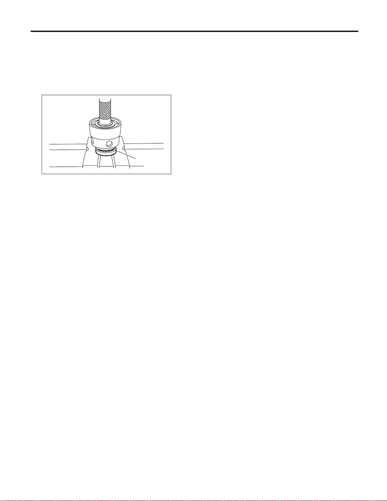

Center Differential

MANUAL TRANSMISSION AND DIFFERENTIAL

D: ASSEMBLY

Install the ball bearings.

CAUTION:

Do not apply a load in excess of 10 kN (1 ton, 1.1 US ton, 1.0 Imp ton).

NOTE:

Use a new ball bearing.

E: INSPECTION

1) Ball bearing

Replace the ball bearing in following cases.

• In case of broken or rusty ball bearings

• In case of worn or damaged ball bearings

• When the ball bearings fail to turn smoothly or emit noise in rotation after gear oil lubrication.

• When the ball bearing has other defects.

2) Center differential

If there is wear or damage, replace the center differential assembly.

MT-01898

(A)

(A) Ball bearing